# Test Multivariate IRT Model

2022-02-08

## FLPS model

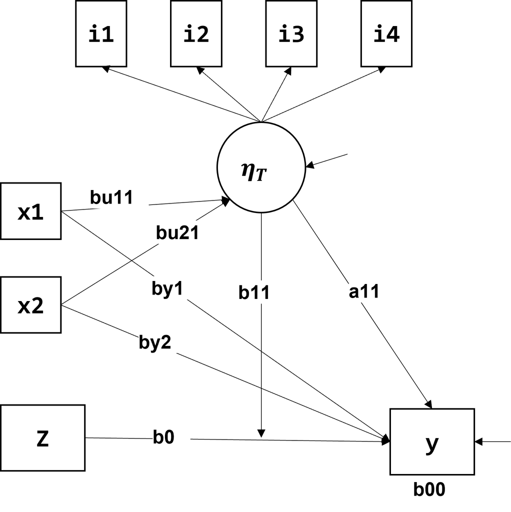

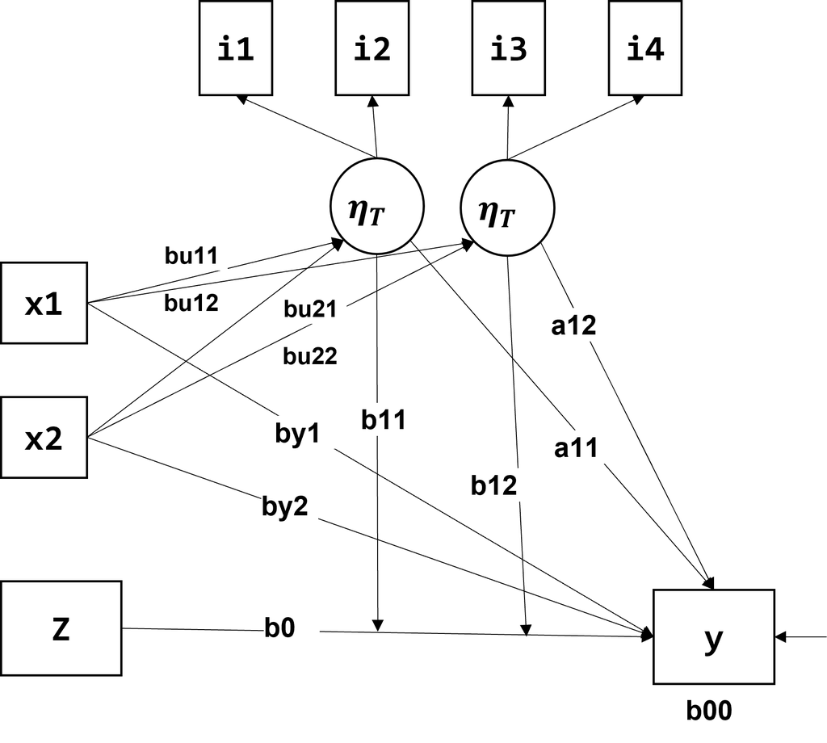

- FLPS models with one factor and two factor

## generate data

- `makeDat()` function generates a list of data, which contains the data (`stan_dt`) for `stan()` to run the FLPS model. The list of data contains all other simulation inputs as well.

### code

```r
# generate data ------------------------------------------
sim_condition <- list(
  N       = 2000,     # sample size
  R2Y     = 0.2,      # strength of effects of covariates
  R2eta   = 0.2,      # strength of effects of latent variable
  omega   = 0.2,      # a11
  tau0    = 0.4,      # b0
  tau1    = -0.2,     # b11
  linear  = T,
  lambda  = 0.6,      # percentage of missing in latent variable models
  nsec    = 20,       # Number of items
  nfac    = 1,        # Number of latent factors
  lvmodel ="2pl"      # Type of latent models: 2pl, gpcm, grm
)

sdat <- do.call("makeDat", sim_condition)
```

### data structure

```r
# a list of data for stan function
str(sdat$stan_dt)
```

```
## List of 16
##  $ nsecWorked  : int 12000
##  $ nstud       : num 2000
##  $ nsec        : num 20
##  $ nfac        : num 1
##  $ min_k       : num 0
##  $ max_k       : num 1
##  $ ncov        : int 2
##  $ studentM    : int [1:12000] 1 1 1 1 1 1 1 1 1 1 ...
##  $ section     : int [1:12000] 1 3 4 5 6 7 8 9 11 12 ...
##  $ lambda_prior: num [1:20, 1] 1 1 1 1 1 1 1 1 1 1 ...
##  $ factoridx   : num [1:20, 1] 1 1 1 1 1 1 1 1 1 1 ...
##  $ firstitem   : num [1:20] 1 0 0 0 0 0 0 0 0 0 ...
##  $ grad        : num [1:12000] 0 0 0 0 0 0 0 1 0 0 ...
##  $ X           : num [1:2000, 1:2] 0.5962 0.7609 -0.0938 1.3749 -0.8105 ...
##   ..- attr(*, "dimnames")=List of 2
##   .. ..$ : NULL
##   .. ..$ : chr [1:2] "x1" "x2"
##  $ Z           : num [1:2000] 1 1 1 1 1 1 1 1 1 1 ...
##  $ Y           : num [1:2000] 2.125 -0.148 1.528 1.599 1.061 ...
```

## Check the generated data

### Check Latent variable model part

- To make sure the item response data is based on the population parameters, I ran `mirt()` and extracted the item parameters using `coef()`. The estimates with the generated response data is on the left-hand side, and the population value is on the right-hand side.

```r
# Generated item parameters
check_lv(
 dat=sdat$lv.resp,
 covdata=NULL,
 lvmodel=sdat$lvmodel,
 nfac=sdat$nfac,
 IRTpars=ifelse(sdat$lvmodel=="gpcm",T,F)
)$items.est %>% round(3)
```

```
##            a1      d g u
## Item_1  1.441 -1.186 0 1
## Item_2  1.950  0.749 0 1
## Item_3  1.249  0.598 0 1
## Item_4  1.863 -0.641 0 1
## Item_5  1.831 -0.876 0 1
## Item_6  1.861 -0.183 0 1
## Item_7  1.658 -1.020 0 1
## Item_8  1.392 -1.021 0 1
## Item_9  2.286 -0.060 0 1
## Item_10 2.262  0.202 0 1
## Item_11 1.585 -1.200 0 1
## Item_12 1.117  1.024 0 1
## Item_13 2.120  0.774 0 1
## Item_14 1.807 -0.199 0 1
## Item_15 1.639 -0.308 0 1
## Item_16 1.671  0.585 0 1
## Item_17 1.568  0.254 0 1
## Item_18 1.490 -0.203 0 1
## Item_19 2.704  0.830 0 1
## Item_20 1.729  0.325 0 1
```

```r
# Population item parameters
#
#
#
#
#
#
sdat$lvinfo$ipar %>% round(3)
```

```
##       a1      d g
## 1  1.000 -1.172 0
## 2  1.430  0.811 0
## 3  0.745  0.656 0
## 4  1.222 -0.592 0
## 5  1.321 -0.927 0
## 6  1.331 -0.021 0
## 7  1.147 -0.981 0
## 8  1.030 -1.038 0
## 9  1.669  0.010 0
## 10 1.650  0.193 0
## 11 1.146 -1.126 0
## 12 0.894  1.076 0
## 13 1.497  0.855 0
## 14 1.247 -0.190 0
## 15 1.078 -0.322 0
## 16 1.201  0.689 0
## 17 1.147  0.204 0
## 18 1.163 -0.113 0
## 19 1.869  0.827 0
## 20 1.247  0.367 0
```

### check flps model part

- To make sure the data is generated by the FLPS model parameters set by the condition, I ran a simple regression with interaction terms (because I have true eta scores) using `lm()`.

```r
check_flps(sdat$stan_dt) %>% round(3)
```

```
##    b00     b0    b11    a11    by1    by2   bu11   bu12
##  0.001  0.402 -0.200  0.220  1.011  0.487 -0.990  0.470
```

## Run `stan()`

- Using `sdat$stan_dt` as an input data for `stan()`, the FLPS model can be conducted. According to the type of latent variable model, different `stan` scripts will be fed into `file`. In this example, the IRT model script is used. Other scripts are:
- 2PL: [multivariate IRT](https://github.com/sooyongl/FLPS/blob/main/inst/stan/psIRT_multi.stan)
- GPCM: [multivariate GPCM](https://github.com/sooyongl/FLPS/blob/main/inst/stan/psGPCM_multi.stan)
- GRM: [multivariate GRM](https://github.com/sooyongl/FLPS/blob/main/inst/stan/psGRM_multi.stan)

```r
fit <- rstan::stan(
  file = "inst/stan/psIRT_multi.stan",
  data = sdat$stan_dt,
  iter = 6000,
  warmup = 2000,
  chains = 1,
  open_progress = F
)
```

## Results

- I ran 3 IRT models (2PL, GPCM, and GRM) varying the number of latent factors (1 and 2).
- With one factor, the estimates are close to the parameter values.
- With two factors, b11 or b12 (interaction effects, tau1) are biased, which needs to be investigated.

### 2PL

#### One factor

##### lambda

```r
table_est(res_list[[1]])$lambda_mat
```

```
## # A tibble: 20 x 2
##    pop.a1 est.a1
##     <dbl>  <dbl>
##  1  1      1
##  2  0.934  0.688
##  3  1.20   0.997
##  4  1.26   1.13
##  5  1.50   1.09
##  6  0.749  0.558
##  7  2.02   1.89
##  8  1.01   0.883
##  9  1.09   0.985
## 10  0.641  0.778
## 11  0.887  0.786
## 12  0.946  0.971
## 13  1.40   1.26
## 14  1.42   1.29
## 15  1.61   1.20
## 16  1.06   0.995
## 17  0.948  0.788
## 18  1.02   1.05
## 19  1.13   0.979
## 20  1.50   1.21
```

##### tau

```r
table_est(res_list[[1]])$tau_mat
```

```
## # A tibble: 20 x 2
##     pop.b1  est.b1
##      <dbl>   <dbl>
##  1  0.625   0.771
##  2  1.60    1.51
##  3 -0.421  -0.393
##  4  0.205   0.267
##  5  1.26    1.14
##  6  0.666   0.692
##  7 -0.539  -0.400
##  8 -0.331  -0.287
##  9 -0.960  -0.818
## 10 -2.52   -2.66
## 11  0.443   0.336
## 12  0.0401 -0.0336
## 13  0.307   0.412
## 14  0.635   0.880
## 15 -0.657  -0.654
## 16  0.106   0.119
## 17 -1.11   -1.17
## 18  0.821   0.867
## 19 -0.210  -0.311
## 20  0.880   0.874
```

##### flps parameters

```r
table_est(res_list[[1]])$flps_param
```

```
## # A tibble: 2 x 9
##   type     b00    b0    b11   a11   by1   by2  bu11  bu12
##   <chr>  <dbl> <dbl>  <dbl> <dbl> <dbl> <dbl> <dbl> <dbl>
## 1 true  0.0178 0.386 -0.209 0.188 0.983 0.490 -1.04 0.497
## 2 est   0.0144 0.389 -0.191 0.182 0.995 0.479 -1.16 0.597
```

##### eta estimates

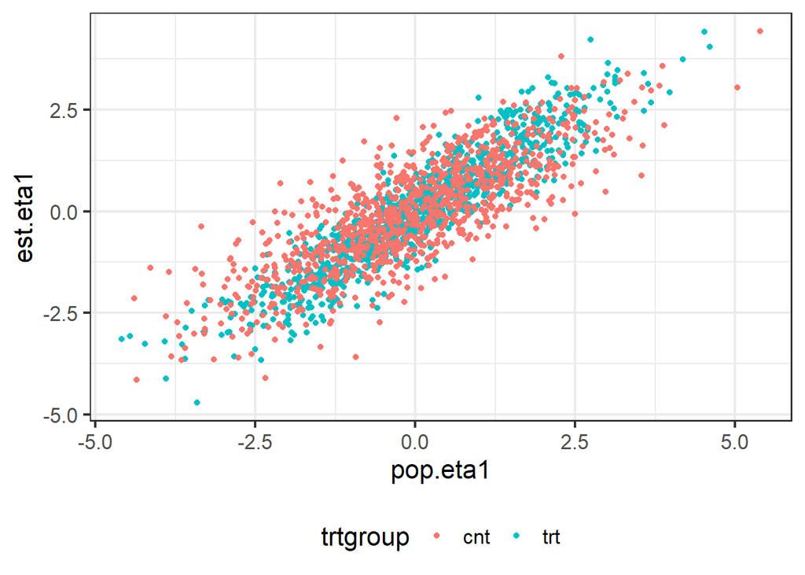

```r
plot_eta(res_list[[1]]$comb_eta)
```

#### Two factor

##### lambda

```r
table_est(res_list[[2]])$lambda_mat
```

```
## # A tibble: 20 x 4
##    pop.a1 pop.a2 est.a1 est.a2
##     <dbl>  <dbl>  <dbl>  <dbl>
##  1  1      0      1      0
##  2  0.855  0      0.810  0
##  3  0.721  0      0.703  0
##  4  1.20   0      1.03   0
##  5  1.68   0      1.45   0
##  6  1.11   0      0.844  0
##  7  0.972  0      0.859  0
##  8  1.41   0      1.34   0
##  9  1.34   0      1.11   0
## 10  1.08   0      1.08   0
## 11  0      1      0      1
## 12  0      1.60   0      1.98
## 13  0      1.22   0      1.10
## 14  0      2.07   0      1.74
## 15  0      0.872  0      0.965
## 16  0      1.19   0      1.12
## 17  0      0.892  0      0.936
## 18  0      1.30   0      1.05
## 19  0      1.52   0      1.22
## 20  0      0.663  0      0.494
```

##### tau

```r
table_est(res_list[[2]])$tau_mat
```

```
## # A tibble: 20 x 2
##    pop.b1  est.b1
##     <dbl>   <dbl>
##  1 -0.802 -0.670
##  2 -0.354 -0.0634
##  3  0.221  0.392
##  4  1.28   1.37
##  5 -0.507 -0.373
##  6  0.939  0.734
##  7 -0.222  0.0172
##  8 -1.37  -1.48
##  9  2.30   2.29
## 10  0.436  0.553
## 11  0.576  0.708
## 12 -1.72  -2.16
## 13 -1.34  -1.33
## 14  0.593  0.513
## 15  0.667  0.710
## 16 -0.358 -0.252
## 17  0.845  1.03
## 18  0.352  0.330
## 19  0.717  0.528
## 20 -0.419 -0.399
```

##### flps parameters

```r
table_est(res_list[[2]])$flps_param
```

```
## # A tibble: 2 x 13
##   type     b00    b0     b11    b12    a11   a12   by1   by2  bu11  bu21   bu12
##   <chr>  <dbl> <dbl>   <dbl>  <dbl>  <dbl> <dbl> <dbl> <dbl> <dbl> <dbl>  <dbl>
## 1 true  0.0485 0.408 -0.193  -0.150 0.183  0.161 0.973 0.521 -1.01 0.503 -0.988
## 2 est   0.0487 0.408 -0.0887 -0.198 0.0494 0.205 0.929 0.534 -1.18 0.567 -1.12
## # ... with 1 more variable: bu22 <dbl>
```

##### eta estimates

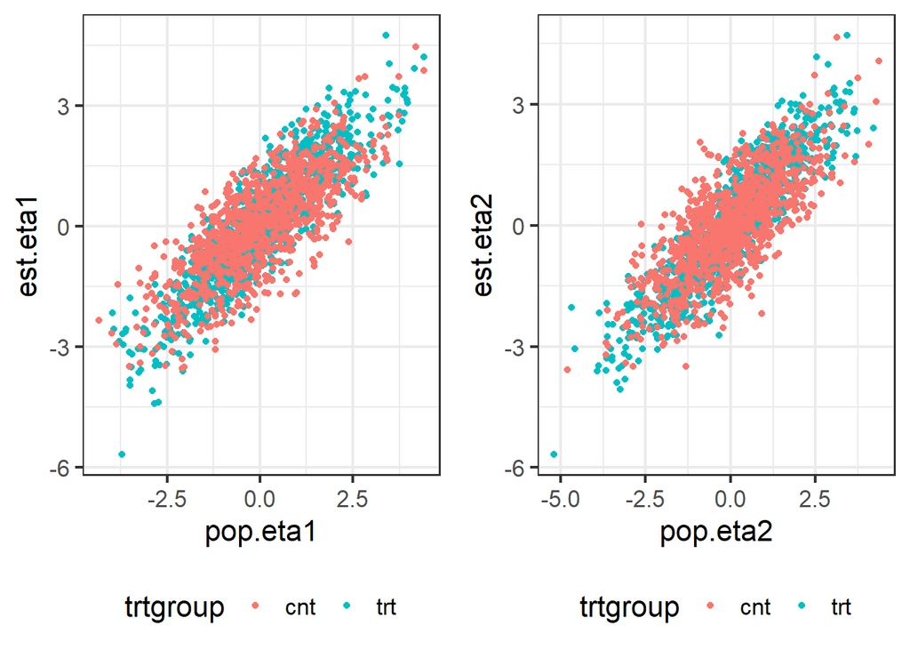

```r
plot_eta(res_list[[2]]$comb_eta)
```

### GPCM

#### One factor

##### lambda

```r
table_est(res_list[[3]])$lambda_mat
```

```
## # A tibble: 20 x 2
##    pop.a1 est.a1
##     <dbl>  <dbl>
##  1  1      1
##  2  1.36   1.18
##  3  1.01   0.945
##  4  0.973  0.864
##  5  1.01   0.957
##  6  0.757  0.758
##  7  1.98   1.67
##  8  0.641  0.522
##  9  0.853  0.807
## 10  1.19   1.02
## 11  1.05   0.919
## 12  1.78   1.63
## 13  1.39   1.28
## 14  1.18   1.07
## 15  1.09   1.07
## 16  0.918  0.767
## 17  1.67   1.56
## 18  1.23   1.02
## 19  1.47   1.27
## 20  1.14   1.31
```

##### tau

```r
table_est(res_list[[3]])$tau_mat
```

```
## # A tibble: 20 x 6
##    pop.b1    pop.b2 pop.b3 est.b1   est.b2 est.b3
##     <dbl>     <dbl>  <dbl>  <dbl>    <dbl>  <dbl>
##  1  0.647  0.141    -0.787  0.676 -0.00480 -0.641
##  2  0.869 -0.0711   -0.798  1.42  -0.0304  -1.30
##  3  0.594 -0.0394   -0.555  0.714 -0.170   -0.376
##  4  0.701  0.0866   -0.788  0.652  0.0764  -0.619
##  5  0.940 -0.0283   -0.912  0.855  0.348   -1.05
##  6  0.787 -0.0985   -0.689  0.503  0.0948  -0.765
##  7  0.748 -0.000282 -0.748  1.94  -0.146   -1.44
##  8  0.778 -0.119    -0.659  0.589 -0.0586  -0.571
##  9  0.937  0.00249  -0.939  0.836 -0.0629  -0.490
## 10  0.691 -0.0791   -0.612  0.694  0.105   -0.686
## 11  0.874  0.0626   -0.936  1.19  -0.330   -0.911
## 12  0.622  0.0827   -0.705  1.35  -0.185   -0.974
## 13  0.751  0.00429  -0.755  1.27   0.242   -1.30
## 14  0.664 -0.0266   -0.637  0.940 -0.0298  -0.744
## 15  0.851 -0.0872   -0.763  1.04  -0.227   -0.836
## 16  0.765  0.000693 -0.766  0.937 -0.447   -0.598
## 17  0.548  0.0304   -0.579  0.981  0.182   -1.07
## 18  0.664 -0.0603   -0.604  0.865  0.198   -0.972
## 19  0.769 -0.0201   -0.749  1.36  -0.0265  -1.22
## 20  0.863  0.0330   -0.896  0.838 -0.0852  -0.504
```

##### flps parameters

```r
table_est(res_list[[3]])$flps_param
```

```
## # A tibble: 2 x 9
##   type       b00    b0    b11   a11   by1   by2   bu11  bu12
##   <chr>    <dbl> <dbl>  <dbl> <dbl> <dbl> <dbl>  <dbl> <dbl>
## 1 true  -0.00524 0.420 -0.150 0.185 0.999 0.457 -0.993 0.470
## 2 est   -0.00458 0.420 -0.135 0.129 0.951 0.475 -1.05  0.549
```

##### eta estimates

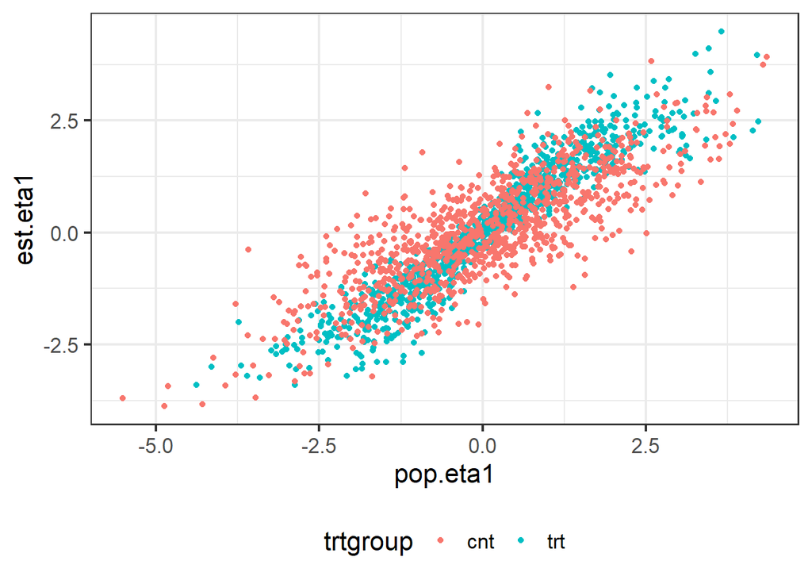

```r
plot_eta(res_list[[3]]$comb_eta)
```

#### Two factor

##### lambda

```r
table_est(res_list[[4]])$lambda_mat
```

```
## # A tibble: 20 x 4
##    pop.a1 pop.a2 est.a1 est.a2
##     <dbl>  <dbl>  <dbl>  <dbl>
##  1  1      0      1      0
##  2  1.58   0      1.48   0
##  3  0.894  0      0.789  0
##  4  1.61   0      1.54   0
##  5  1.01   0      0.969  0
##  6  1.13   0      1.09   0
##  7  0.834  0      0.851  0
##  8  1.48   0      1.37   0
##  9  0.921  0      0.672  0
## 10  1.12   0      0.970  0
## 11  0      1      0      1
## 12  0      1.39   0      1.15
## 13  0      1.30   0      1.06
## 14  0      0.988  0      0.866
## 15  0      1.45   0      1.13
## 16  0      0.745  0      0.682
## 17  0      1.17   0      1.02
## 18  0      1.13   0      1.22
## 19  0      1.09   0      0.941
## 20  0      1.07   0      0.920
```

##### tau

```r
table_est(res_list[[4]])$tau_mat
```

```
## # A tibble: 20 x 6
##    pop.b1    pop.b2 pop.b3 est.b1  est.b2  est.b3
##     <dbl>     <dbl>  <dbl>  <dbl>   <dbl>   <dbl>
##  1  0.661 -0.00464  -0.656  0.728 -0.161  -0.570
##  2  0.906  0.00828  -0.914  1.28  -0.311  -1.22
##  3  0.554  0.0437   -0.598  0.498  0.0316 -0.616
##  4  0.676  0.0789   -0.755  1.07   0.133  -1.22
##  5  0.720  0.0821   -0.802  0.534  0.123  -0.996
##  6  0.702  0.142    -0.844  1.10  -0.204  -0.947
##  7  0.508 -0.000271 -0.507  0.324 -0.305  -0.0358
##  8  0.693 -0.0930   -0.600  0.912 -0.370  -0.730
##  9  0.934 -0.0636   -0.870  1.02  -0.111  -1.09
## 10  0.742  0.0833   -0.825  0.733  0.0716 -0.887
## 11  0.605 -0.0109   -0.594  0.415  0.238  -0.608
## 12  0.909 -0.0178   -0.891  1.60  -0.474  -1.16
## 13  0.772  0.0235   -0.795  1.08   0.358  -1.60
## 14  0.597  0.0683   -0.666  0.497  0.136  -0.651
## 15  0.855 -0.126    -0.729  1.56  -0.589  -1.16
## 16  0.638  0.0159   -0.654  0.507 -0.0467 -0.388
## 17  0.908  0.0364   -0.945  1.12  -0.0666 -1.14
## 18  0.661  0.0244   -0.686  0.523  0.0511 -0.506
## 19  0.690  0.0745   -0.764  0.855 -0.0185 -0.946
## 20  0.699  0.0200   -0.719  0.666  0.175  -1.04
```

##### flps parameters

```r
table_est(res_list[[4]])$flps_param
```

```
## # A tibble: 2 x 13
##   type      b00    b0     b11    b12      a11   a12   by1   by2   bu11  bu21
##   <chr>   <dbl> <dbl>   <dbl>  <dbl>    <dbl> <dbl> <dbl> <dbl>  <dbl> <dbl>
## 1 true  -0.0556 0.435 -0.269  -0.143  0.206   0.187  1.02 0.532 -0.984 0.502
## 2 est   -0.0670 0.444 -0.0601 -0.304 -0.00422 0.355  1.02 0.534 -1.08  0.585
## # ... with 2 more variables: bu12 <dbl>, bu22 <dbl>
```

##### eta estimates

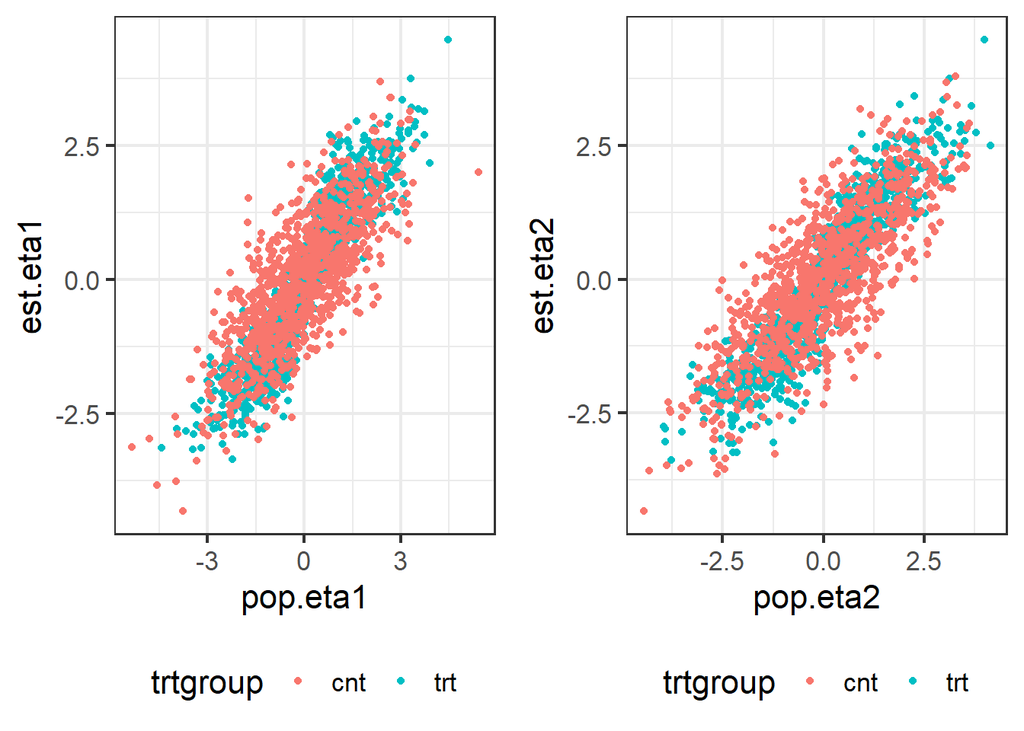

```r
plot_eta(res_list[[4]]$comb_eta)
```

### GRM

#### One factor

##### lambda

```r
table_est(res_list[[5]])$lambda_mat
```

```
## # A tibble: 20 x 2
##    pop.a1 est.a1
##     <dbl>  <dbl>
##  1  1      1
##  2  1.60   1.40
##  3  1.95   1.98
##  4  0.574  0.527
##  5  1.19   1.14
##  6  0.763  0.671
##  7  0.994  0.992
##  8  0.808  0.717
##  9  1.77   1.40
## 10  1.62   1.53
## 11  1.28   1.09
## 12  2.04   2.02
## 13  0.692  0.623
## 14  0.787  0.600
## 15  0.959  0.775
## 16  1.16   1.20
## 17  0.490  0.520
## 18  1.46   1.41
## 19  0.890  0.639
## 20  0.693  0.626
```

##### tau

```r
table_est(res_list[[5]])$tau_mat
```

```
## # A tibble: 20 x 6
##    pop.b1   pop.b2 pop.b3 est.b1   est.b2 est.b3
##     <dbl>    <dbl>  <dbl>  <dbl>    <dbl>  <dbl>
##  1  0.683  0.145   -0.829  0.689  0.166   -0.758
##  2  0.728  0.127   -0.855  0.604  0.0227  -0.885
##  3  0.692  0.0980  -0.790  0.848  0.291   -0.645
##  4  0.892 -0.0375  -0.854  1.02   0.0893  -0.823
##  5  0.592  0.0460  -0.638  0.714  0.146   -0.577
##  6  0.554  0.0281  -0.582  0.574  0.0187  -0.506
##  7  0.723  0.0613  -0.785  0.800  0.126   -0.671
##  8  0.767 -0.00185 -0.765  0.853  0.0935  -0.733
##  9  0.635  0.123   -0.758  0.712  0.206   -0.547
## 10  0.806 -0.00946 -0.797  0.770 -0.154   -0.782
## 11  0.721  0.0478  -0.769  0.836  0.172   -0.634
## 12  0.939 -0.0159  -0.923  1.02  -0.0758  -1.14
## 13  0.853 -0.0600  -0.793  0.798 -0.103   -0.775
## 14  0.705  0.0146  -0.719  0.542 -0.0272  -0.794
## 15  0.748  0.00838 -0.757  0.718  0.0522  -0.774
## 16  0.709  0.0760  -0.785  0.772  0.159   -0.818
## 17  0.633 -0.00600 -0.627  0.618  0.00923 -0.595
## 18  0.944 -0.00335 -0.940  1.05   0.111   -1.01
## 19  0.858 -0.0827  -0.776  0.916  0.0154  -0.686
## 20  0.767 -0.101   -0.666  0.714 -0.185   -0.668
```

##### flps parameters

```r
table_est(res_list[[5]])$flps_param
```

```
## # A tibble: 2 x 9
##   type     b00    b0    b11   a11   by1   by2  bu11  bu12
##   <chr>  <dbl> <dbl>  <dbl> <dbl> <dbl> <dbl> <dbl> <dbl>
## 1 true  0.0198 0.388 -0.176 0.198 0.989 0.487 -1.01 0.509
## 2 est   0.0133 0.395 -0.155 0.166 0.984 0.490 -1.17 0.585
```

##### eta estimates

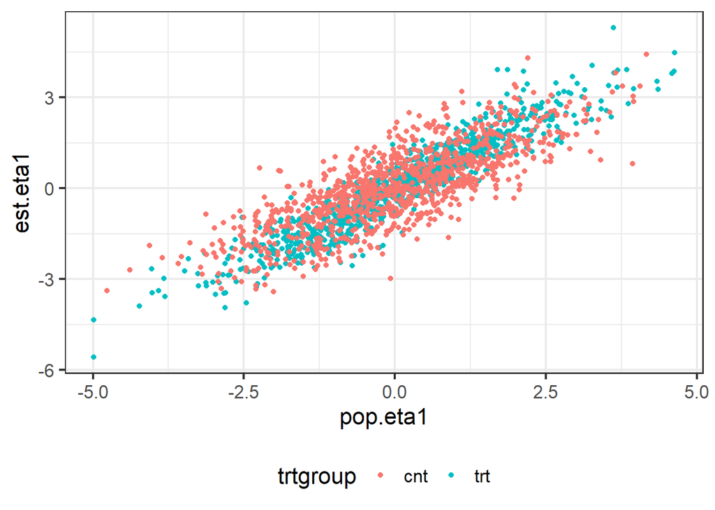

```r
plot_eta(res_list[[5]]$comb_eta)
```

#### Two factor

##### lambda

```r
table_est(res_list[[6]])$lambda_mat
```

```
## # A tibble: 20 x 4
##    pop.a1 pop.a2 est.a1 est.a2
##     <dbl>  <dbl>  <dbl>  <dbl>
##  1  1      0      1      0
##  2  1.55   0      1.33   0
##  3  0.586  0      0.549  0
##  4  1.10   0      1.08   0
##  5  1.70   0      1.47   0
##  6  0.769  0      0.752  0
##  7  1.47   0      1.37   0
##  8  0.969  0      1.19   0
##  9  1.30   0      1.26   0
## 10  1.48   0      1.60   0
## 11  0      1      0      1
## 12  0      0.970  0      0.863
## 13  0      1.77   0      1.96
## 14  0      2.09   0      2.06
## 15  0      1.49   0      1.34
## 16  0      0.804  0      0.798
## 17  0      0.874  0      0.703
## 18  0      0.822  0      0.785
## 19  0      1.56   0      1.42
## 20  0      1.16   0      1.16
```

##### tau

```r
table_est(res_list[[6]])$tau_mat
```

```
## # A tibble: 20 x 6
##    pop.b1    pop.b2 pop.b3 est.b1   est.b2 est.b3
##     <dbl>     <dbl>  <dbl>  <dbl>    <dbl>  <dbl>
##  1  0.690  0.0919   -0.781  0.756  0.214   -0.791
##  2  0.719  0.0915   -0.810  0.713  0.170   -0.795
##  3  0.856  0.0103   -0.866  0.763 -0.0449  -0.978
##  4  0.647  0.0158   -0.663  0.671  0.00505 -0.906
##  5  0.669  0.0646   -0.733  0.466 -0.0343  -0.860
##  6  0.676  0.0281   -0.704  0.732  0.0288  -0.700
##  7  0.704  0.0590   -0.763  0.902  0.217   -0.614
##  8  0.809 -0.0350   -0.774  1.02  -0.0268  -0.973
##  9  0.691  0.121    -0.811  0.713  0.165   -0.754
## 10  0.639  0.0575   -0.697  0.690  0.0164  -0.830
## 11  0.550  0.0178   -0.568  0.615  0.0139  -0.552
## 12  0.784  0.000688 -0.785  0.766 -0.0950  -0.945
## 13  0.888 -0.109    -0.779  0.892 -0.157   -0.875
## 14  0.660 -0.0302   -0.629  0.868  0.101   -0.526
## 15  0.745  0.0321   -0.778  0.517 -0.0878  -0.855
## 16  0.671  0.0932   -0.765  0.670  0.0669  -0.766
## 17  0.645  0.0726   -0.718  0.520 -0.0531  -0.666
## 18  0.820 -0.121    -0.698  0.738 -0.203   -0.748
## 19  0.762 -0.128    -0.633  0.611 -0.272   -0.715
## 20  0.616  0.0677   -0.684  0.668  0.0834  -0.679
```

##### flps parameters

```r
table_est(res_list[[6]])$flps_param
```

```
## # A tibble: 2 x 13
##   type      b00    b0    b11    b12   a11   a12   by1   by2  bu11  bu21   bu12
##   <chr>   <dbl> <dbl>  <dbl>  <dbl> <dbl> <dbl> <dbl> <dbl> <dbl> <dbl>  <dbl>
## 1 true  -0.0367 0.484 -0.193 -0.189 0.187 0.187 0.980 0.499 -1.01 0.500 -0.996
## 2 est   -0.0358 0.483 -0.138 -0.264 0.140 0.256 0.997 0.497 -1.05 0.478 -1.03
## # ... with 1 more variable: bu22 <dbl>
```

##### eta estimates

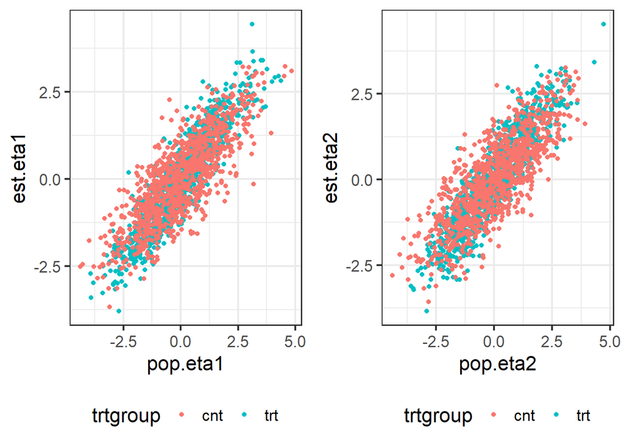

```r
plot_eta(res_list[[6]]$comb_eta)
```